# RLadies - Modelowanie. Wstęp do klasyfikacji

A.Brodecka

7 października 2017

# Wstęp

Analizujemy dane dotyczące katastrofy statku morskiego z 1912 roku, Titanica. Dane mają następującą postać:

```r
dane %<>% select(-c(PassengerId,Name, Ticket, Cabin))
head(dane)
```

```
##   Survived Pclass    Sex Age SibSp Parch    Fare Embarked
## 1        0      3   male  22     1     0  7.2500        S
## 2        1      1 female  38     1     0 71.2833        C
## 3        1      3 female  26     0     0  7.9250        S
## 4        1      1 female  35     1     0 53.1000        S
## 5        0      3   male  35     0     0  8.0500        S
## 6        0      3   male  NA     0     0  8.4583        Q
```

Opis zmiennych:

- Survival - Czy pasażer przeżył katastrofę: 0 = Nie, 1 = Tak
- Pclass - Klasa biletu pasażera
- Sex - Płeć
- Age - Wiek
- Sibsp - Liczba rodzeństwa/Małżonków na pokładzie
- Parch - Liczba rodziców/dzieci na pokładzie
- Fare - Opłata pasażera
- Embarked - Port zaokrętowania: C = Cherbourg, Q = Queenstown, S = Southampton

Na początek sprawdźmy ile mamy ocalonych w zbiorze:

```r
table(dane$Survived)
```

```
##
##   0   1
## 549 342
```

Sprawdzamy braki danych:

```r
apply(dane, 2, FUN = function(x){
  any(is.na(x))}
  )
```

```
## Survived   Pclass      Sex      Age    SibSp    Parch     Fare Embarked
##    FALSE    FALSE    FALSE     TRUE    FALSE    FALSE    FALSE    FALSE
```

Uzupełnijmy braki medianą wieku:

```r
m.Age <- median(dane$Age, na.rm = TRUE)
dane %<>% mutate(Age = if_else(is.na(Age),m.Age ,Age))
```

Rozkodujmy zmienne kategoryczne na zmienne 0-1 pomijając pierwszy poziom odniesienia:

```r
dane <- model.matrix(~.-1 , data=dane) %>% data.frame() %>%
    select(-c(EmbarkedC,Sexmale))
```

Na koniec przygotujmy zbiór treningowy: 70% obserwacji i zbiór testowy: 30% obserwacji :

```r
set.seed(555)
los <- sample(1:nrow(dane), ceiling(0.7*nrow(dane)),replace = F)
train <- dane[los,]
test <- dane[-los,]
```

Tworzymy funkcję do weryfikacji predykcji naszego klasyfikatora:

```r
check_class <- function(true, pred){
  t <- table(true, pred)
  results <- c(sum(diag(t))/sum(t), t[2,2]/sum(t[2,]), t[2,2]/sum(t[,2]), t[1,1]/sum(t[,1]))
  names(results) <- c("% popr. odp.", "czułość", "precyzja", "specyficzność")
  results
}
```

# Regresja logistyczna

Model logistyczny dopasowany do wszystkich zmiennych:

W tym przypadku korzystamy z logitowej funkcji łączącej.

```r
logit <- glm(Survived ~ ., family=binomial(link=logit), data=train)
```

Żeby skorzystać z innych funkcji łączących wystarczy zmienić argument ‘link’:

```r
probit <- glm(Survived ~ ., family=binomial(link="probit"), data=train)
cloglog <- glm(Survived ~ ., family=binomial(link="cloglog"), data=train)
```

Podsumowanie modelu:

```r
summary(logit)
```

```
##
## Call:
## glm(formula = Survived ~ ., family = binomial(link = logit),
##     data = train)
##
## Deviance Residuals:
##     Min       1Q   Median       3Q      Max
## -2.0490  -0.5964  -0.4179   0.6385   2.2769
##
## Coefficients:
##              Estimate Std. Error z value Pr(>|z|)
## (Intercept)  2.343447   0.632425   3.705 0.000211 ***
## Pclass      -1.090591   0.175676  -6.208 5.37e-10 ***
## Sexfemale    2.624795   0.233972  11.218  < 2e-16 ***
## Age         -0.040233   0.009770  -4.118 3.82e-05 ***
## SibSp       -0.286364   0.133261  -2.149 0.031643 *
## Parch       -0.083423   0.147008  -0.567 0.570396
## Fare         0.003564   0.002959   1.204 0.228430
## EmbarkedQ    0.111083   0.463706   0.240 0.810675
## EmbarkedS   -0.219450   0.287220  -0.764 0.444837
## ---
## Signif. codes:  0 '***' 0.001 '**' 0.01 '*' 0.05 '.' 0.1 ' ' 1
##
## (Dispersion parameter for binomial family taken to be 1)
##
##     Null deviance: 826.65  on 623  degrees of freedom
## Residual deviance: 553.13  on 615  degrees of freedom
## AIC: 571.13
##
## Number of Fisher Scoring iterations: 5
```

Sprawdzenie, czy zmienna jest istotna w naszym modelu odbywa się za pomocą testu Walda. W tym wypadku zmienne Pclass, Age, Sexfemale są istotne na poziomie mniejszym niż 0.001. Warto zwrócić uwagę na oszacowania parametrów $\beta.$ Dodatnie wartości wskazują na zwiększenie prawdopodobieństwa przeżycia, ujemne - na zmniejszenie prawdopodobieństwa przeżycia.

Iloraz szans możemy policzyć przez:

```r
exp(coef(logit))
```

```
## (Intercept)      Pclass   Sexfemale         Age       SibSp       Parch
##  10.4170844   0.3360177  13.8017487   0.9605659   0.7509892   0.9199624
##        Fare   EmbarkedQ   EmbarkedS
##   1.0035700   1.1174879   0.8029601
```

Sprawdźmy czy model można uprościć. Skorzystamy z testu Chi-kwadrat i porównania AIC lub BIC. Direction “backward” wskazuje, że wychodzimy z modelu pełnego i staramy się odrzucić kolejno zmienne by zminimalizować kryterium AIC lub BIC.

```r
# logit.aic <- step(logit, direction="backward")
logit.bic <- step(logit, direction = "backward", k = log(nrow(train)))
```

```
## Start:  AIC=611.06
## Survived ~ Pclass + Sexfemale + Age + SibSp + Parch + Fare +
##     EmbarkedQ + EmbarkedS
##
##             Df Deviance    AIC
## - EmbarkedQ  1   553.19 604.68
## - Parch      1   553.46 604.95
## - EmbarkedS  1   553.71 605.20
## - Fare       1   554.83 606.32
## - SibSp      1   558.40 609.88
## <none>           553.13 611.06
## - Age        1   571.45 622.94
## - Pclass     1   591.56 643.05
## - Sexfemale  1   708.05 759.54
##
## Step:  AIC=604.68
## Survived ~ Pclass + Sexfemale + Age + SibSp + Parch + Fare +
##     EmbarkedS
##
##             Df Deviance    AIC
## - Parch      1   553.56 598.62
## - EmbarkedS  1   554.28 599.33
## - Fare       1   554.86 599.91
## - SibSp      1   558.44 603.50
## <none>           553.19 604.68
## - Age        1   571.45 616.50
## - Pclass     1   593.11 638.16
## - Sexfemale  1   710.42 755.47
##
## Step:  AIC=598.62
## Survived ~ Pclass + Sexfemale + Age + SibSp + Fare + EmbarkedS
##
##             Df Deviance    AIC
## - EmbarkedS  1   554.74 593.35
## - Fare       1   554.98 593.60
## <none>           553.56 598.62
## - SibSp      1   560.07 598.69
## - Age        1   571.78 610.39
## - Pclass     1   595.27 633.89
## - Sexfemale  1   714.85 753.47
```

[output cut: 15 more lines]

```
##             Df Deviance    AIC
## - SibSp      1   563.06 588.81
## <none>           556.69 588.87
## - Age        1   575.86 601.61
## - Pclass     1   632.98 658.72
## - Sexfemale  1   727.03 752.78
##
## Step:  AIC=588.81
## Survived ~ Pclass + Sexfemale + Age
##
##             Df Deviance    AIC
## <none>           563.06 588.81
## - Age        1   579.07 598.38
## - Pclass     1   639.61 658.92
## - Sexfemale  1   729.05 748.35
```

```r
summary(logit.bic)
```

```
##
## Call:
## glm(formula = Survived ~ Pclass + Sexfemale + Age, family = binomial(link = logit),
##     data = train)
##
## Deviance Residuals:
##     Min       1Q   Median       3Q      Max
## -1.9907  -0.6475  -0.4314   0.6273   2.2599
##
## Coefficients:
##             Estimate Std. Error z value Pr(>|z|)
## (Intercept)  2.26103    0.51216   4.415 1.01e-05 ***
## Pclass      -1.19216    0.14613  -8.158 3.40e-16 ***
## Sexfemale    2.57219    0.22042  11.669  < 2e-16 ***
## Age         -0.03616    0.00933  -3.876 0.000106 ***
## ---
## Signif. codes:  0 '***' 0.001 '**' 0.01 '*' 0.05 '.' 0.1 ' ' 1
##
## (Dispersion parameter for binomial family taken to be 1)
##
##     Null deviance: 826.65  on 623  degrees of freedom
## Residual deviance: 563.06  on 620  degrees of freedom
## AIC: 571.06
##
## Number of Fisher Scoring iterations: 5
```

Korzystamy z testu Chi-kwadrat:

```r
anova(logit.bic, logit, test = "Chisq")
```

```
## Analysis of Deviance Table
##
## Model 1: Survived ~ Pclass + Sexfemale + Age
## Model 2: Survived ~ Pclass + Sexfemale + Age + SibSp + Parch + Fare +
##     EmbarkedQ + EmbarkedS
##   Resid. Df Resid. Dev Df Deviance Pr(>Chi)
## 1       620     563.06
## 2       615     553.13  5    9.932  0.07719 .
## ---
## Signif. codes:  0 '***' 0.001 '**' 0.01 '*' 0.05 '.' 0.1 ' ' 1
```

Duże p-wartoci => przyjmujemy hipoteze zerowa (nie ma podstaw do odrzucenia hipotezy zerowej) że model może być uproszczony do mniejszego, małe p-wartości => odrzucamy hipotezę zerową i przyjmujemy że w modelu ‘dużym’ znajdują się istotne zmienne.

Do modelu możemy łatwo dodawać przekształcenia zmiennych:

```r
logit.bic.2 <- glm(Survived~ Pclass + Sexfemale + Age  +
                      I(Age^2) , data=train, family="binomial")
```

```r
anova(logit.bic,logit.bic.2, test = "Chisq")
```

```
## Analysis of Deviance Table
##
## Model 1: Survived ~ Pclass + Sexfemale + Age
## Model 2: Survived ~ Pclass + Sexfemale + Age + I(Age^2)
##   Resid. Df Resid. Dev Df Deviance Pr(>Chi)
## 1       620     563.06
## 2       619     561.31  1   1.7571    0.185
```

W przypadku zmiennych ciągłych możemy sprawdzić jaka powinna być prawidłowa postać zmiennych rysując wykresy częściowych rezyduów:

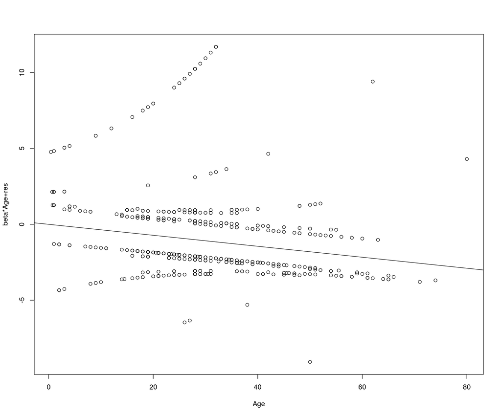

```r
prplot(logit.bic,3)
```

Widać, że występuje tutaj zależność liniowa, dlatego kwadrat zmiennej nie ma wpływu na prawdopodobieństwo zdarzenia.

Ogólne dopasowanie modelu możemy sprawdzić rysując wykres reszt modelowych:

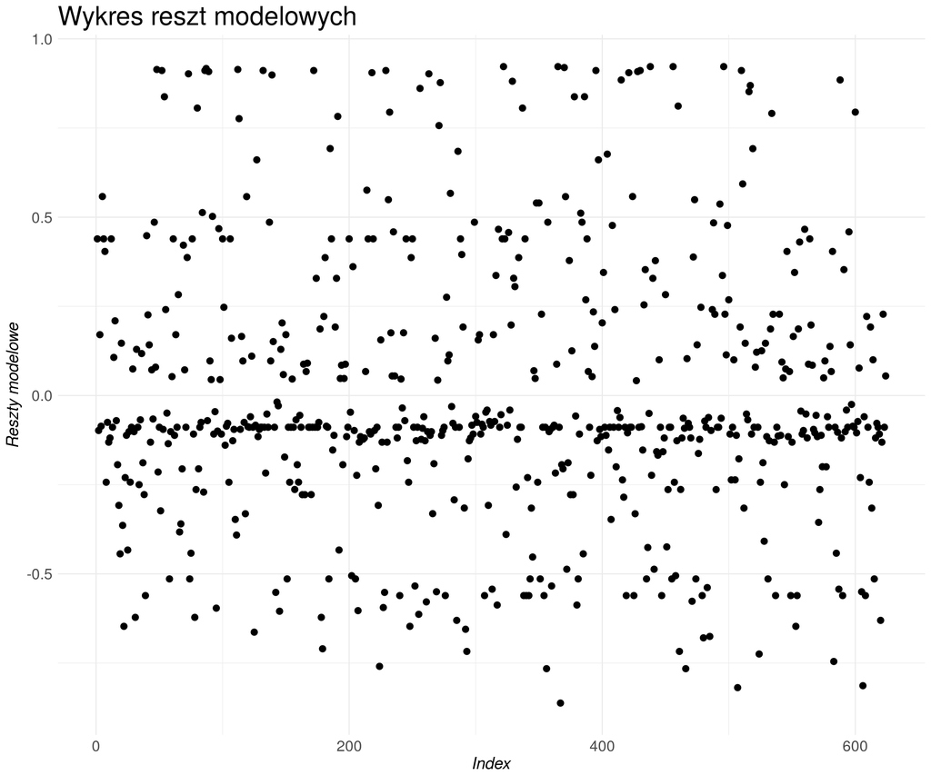

```r
r_resp <- residuals(logit.bic, type='response')
qplot(y = r_resp, x = 1:length(r_resp)) + ggtitle("Wykres reszt modelowych") +
  geom_point(size = 2.5) + labs(y = "Reszty modelowe", x = "Index") + theme_minimal() +
  theme(axis.title.x = element_text(size = 15, angle = 0, face = "italic"),
        axis.title.y = element_text(size = 15, angle = 90, face = "italic")) +
  theme(legend.title = element_text(size = 14, face = "bold")) +
  theme(legend.text = element_text(colour = "black", size = 12)) +
  guides(color = guide_legend(keywidth = 2, keyheight = 2)) + theme(title = element_text(size = 20)) + theme(axis.text= element_text(size = 14))
```

Można również sprawdzić obserwacje potencjalnie odstające:

```r
outlier <- which(abs(logit.bic$residuals)/sqrt(1-hatvalues(logit.bic))>2)
train[outlier[1:5],]
```

```
##     Survived Pclass Sexfemale Age SibSp Parch    Fare EmbarkedQ EmbarkedS
## 573        1      1         0  36     0     0 26.3875         0         1
## 50         0      3         1  18     1     0 17.8000         0         1
## 403        0      3         1  21     1     0  9.8250         0         1
## 594        0      3         1  28     0     2  7.7500         1         0
## 82         1      3         0  29     0     0  9.5000         0         1
```

Funkcja predict zwraca wartości prawdopodobieństwa przynależności do klasy 1:

```r
predict(logit.bic, data.frame(Pclass=1, Sexfemale = 0,Age = 24,
                              SibSp = 0), se.fit=T, type='response')$fit
```

```
##       1
## 0.55009
```

Sprawdzenie dla danych testowych:

```r
probs <- predict(logit.bic, test,type='response')
```

Ważne! Uzyskane prawdopodobieństwa nie określają nam jeszcze klasy! Należy wyznaczyć samodzielnie próg powyżej którego klasyfikujemy obserwacje do klasy 1.

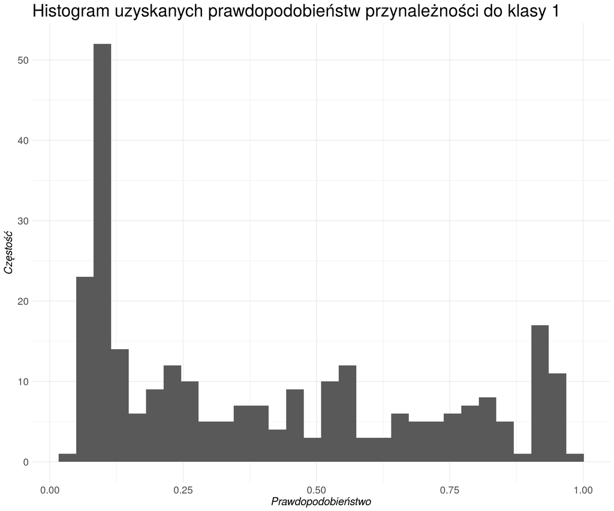

```r
qplot(probs) + ggtitle("Histogram uzyskanych prawdopodobieństw przynależności do klasy 1") +
 labs(y = "Częstość", x = "Prawdopodobieństwo") + theme_minimal() +
  theme(axis.title.x = element_text(size = 15, angle = 0, face = "italic"),
        axis.title.y = element_text(size = 15, angle = 90, face = "italic")) +
  theme(legend.title = element_text(size = 14, face = "bold")) +
  theme(legend.text = element_text(colour = "black", size = 12)) +
  guides(color = guide_legend(keywidth = 2, keyheight = 2)) + theme(title = element_text(size = 20)) + theme(axis.text= element_text(size = 14))
```

Klasyfikuję do klasy 1 obserwcje powyżej 0.6:

```r
class <- ifelse(probs > 0.6,1,0)
```

Wynik klasyfikacji:

```r
c1 <- check_class(test$Survived, class)
c1
```

```
##  % popr. odp.       czułość      precyzja specyficzność
##     0.7902622     0.5887850     0.8400000     0.7708333
```

Wynik klasyfikacji bez uproszczenia modelu:

```r
probs.logit <- predict(logit, test,type='response')
class.logit <- ifelse(probs.logit > 0.6,1,0)
c2 <- check_class(test$Survived, class.logit)
c2
```

```
##  % popr. odp.       czułość      precyzja specyficzność
##     0.8277154     0.6728972     0.8674699     0.8097826
```

Klasyfikacja na podstawie lasso:

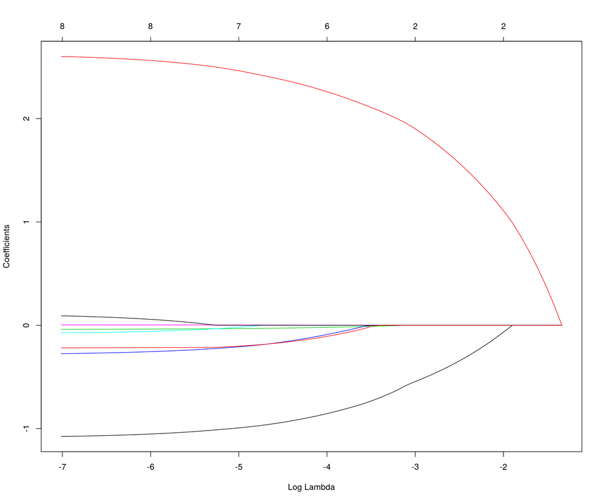

```r
library(glmnet)
logit.lasso <- glmnet(y = as.factor(train$Survived), x= as.matrix(train[,-1]),
                      alpha=1, family="binomial")

plot(logit.lasso, xvar = 'lambda')
```

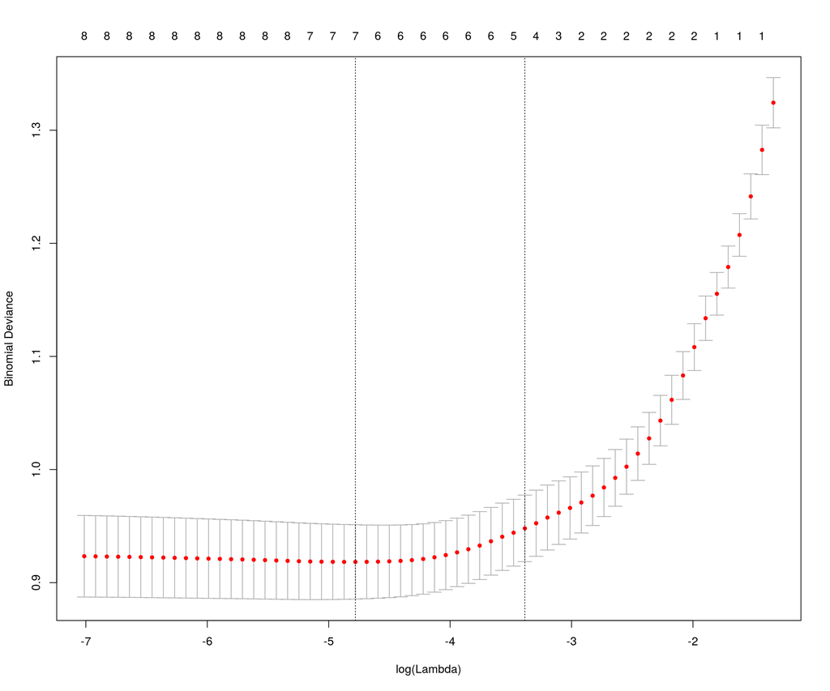

```r
cv.glmmod <- cv.glmnet(y = as.factor(train$Survived),
                       x= as.matrix(train[,-1]), alpha=1, family="binomial")
plot(cv.glmmod)
```

```r
(best.lambda <- cv.glmmod$lambda.min)
```

```
## [1] 0.008395472
```

```r
(best.lambda.se <- cv.glmmod$lambda.1se)
```

```
## [1] 0.03389266
```

```r
logit.lasso.lambda <- glmnet(y = train$Survived, x= as.matrix(train[,-1]),
                      alpha=1, family="binomial", lambda = best.lambda)

coef(cv.glmmod, s = best.lambda)
```

```
## 9 x 1 sparse Matrix of class "dgCMatrix"
##                        1
## (Intercept)  1.820727804
## Pclass      -0.973220823
## Sexfemale    2.426041053
## Age         -0.030141969
## SibSp       -0.192009461
## Parch       -0.003007741
## Fare         0.002142270
## EmbarkedQ    .
## EmbarkedS   -0.189476245
```

```r
lasso.prob <- predict(cv.glmmod,newx = as.matrix(test[,-1]),
                      s=best.lambda,type="response")
```

## Problem separowalności klas:

```r
dane <- read.table('/home/abrodecka/Pulpit/RLadies2/carrots_workshop/modelowanie/data/earthquake.txt', h = T)
```

```r
head(dane)
```

```
##     popn body surface
## 1 equake 5.60    4.25
## 2 equake 5.18    3.93
## 3 equake 6.31    6.30
## 4 equake 5.36    4.49
## 5 equake 5.96    6.39
## 6 equake 5.26    4.42
```

Powyższe dane dotyczą wstrząsów sejsmologicznych:

- popn - rodzaj wstrząsu: equake - trzęsienie ziemi, explosn - wybuch nuklearny
- body - magnituda fali szerokiej
- surface - magnituda fali powierzchniowej

Chcemy zaklasyfikować rodzaj wstrząsu na podstawie zmiennych body i surface.

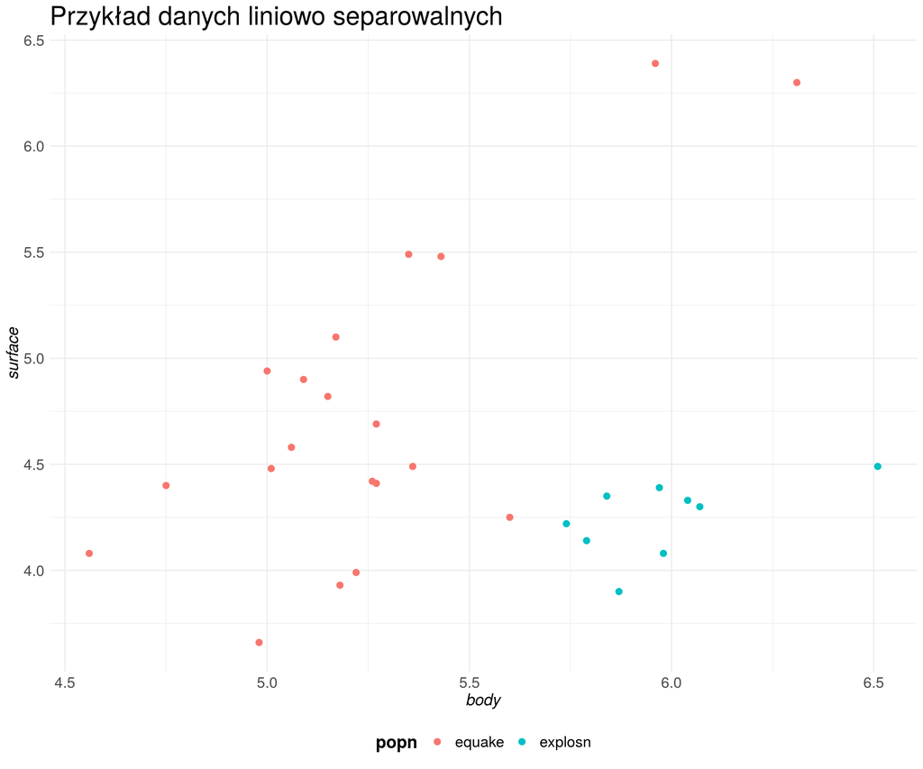

```r
ggplot(data = dane, aes(x = body, y = surface, col = popn))+
  geom_point(size = 2.5) + theme_minimal() + ggtitle("Przykład danych liniowo separowalnych") +
  theme(axis.title.x = element_text(size = 15, angle = 0, face = "italic"),
        axis.title.y = element_text(size = 15, angle = 90, face = "italic")) +
  theme(legend.title = element_text(size = 14, face = "bold")) + theme(title = element_text(size = 20)) +
  theme(legend.text = element_text(colour = "black", size = 12)) +
  guides(color = guide_legend(keywidth = 2, keyheight = 2)) + theme(legend.position = "bottom") +
  theme(axis.text= element_text(size = 14)) +
  theme(legend.title = element_text(size = 16, face = "bold")) +
  theme(legend.text = element_text(colour = "black", size = 14))
```

Dopasowujemy model logistyczny:

```r
model <- glm(popn ~ ., data = dane, family = "binomial")
summary(model)
```

```
##
## Call:
## glm(formula = popn ~ ., family = "binomial", data = dane)
##
## Deviance Residuals:
##        Min          1Q      Median          3Q         Max
## -4.195e-05  -2.100e-08  -2.100e-08   2.100e-08   4.393e-05
##
## Coefficients:
##               Estimate Std. Error z value Pr(>|z|)
## (Intercept)   -1151.09 1000874.08  -0.001    0.999
## body            276.21  190711.00   0.001    0.999
## surface         -98.01  118520.53  -0.001    0.999
##
## (Dispersion parameter for binomial family taken to be 1)
##
##     Null deviance: 3.5924e+01  on 28  degrees of freedom
## Residual deviance: 3.7043e-09  on 26  degrees of freedom
## AIC: 6
##
## Number of Fisher Scoring iterations: 25
```

Widzimy bardzo duże wartości wyestymowanych parametrów oraz ich błędów standardowych. Są to tak duże wartości, że testy istotności pojedynczych zmiennych mają bardzo duże wartości krytyczne. Poza tym widzimy, że algorytm wykonał maksymalną liczbę iteracji (domyślnie 25.) Wynikiem tego problemu jest liniowa separowalność klas.

# Klasyfikacja za pomocą drzew

Separowalność klas nie jest problem w przypadku klasyfikacji za pomocą drzew:

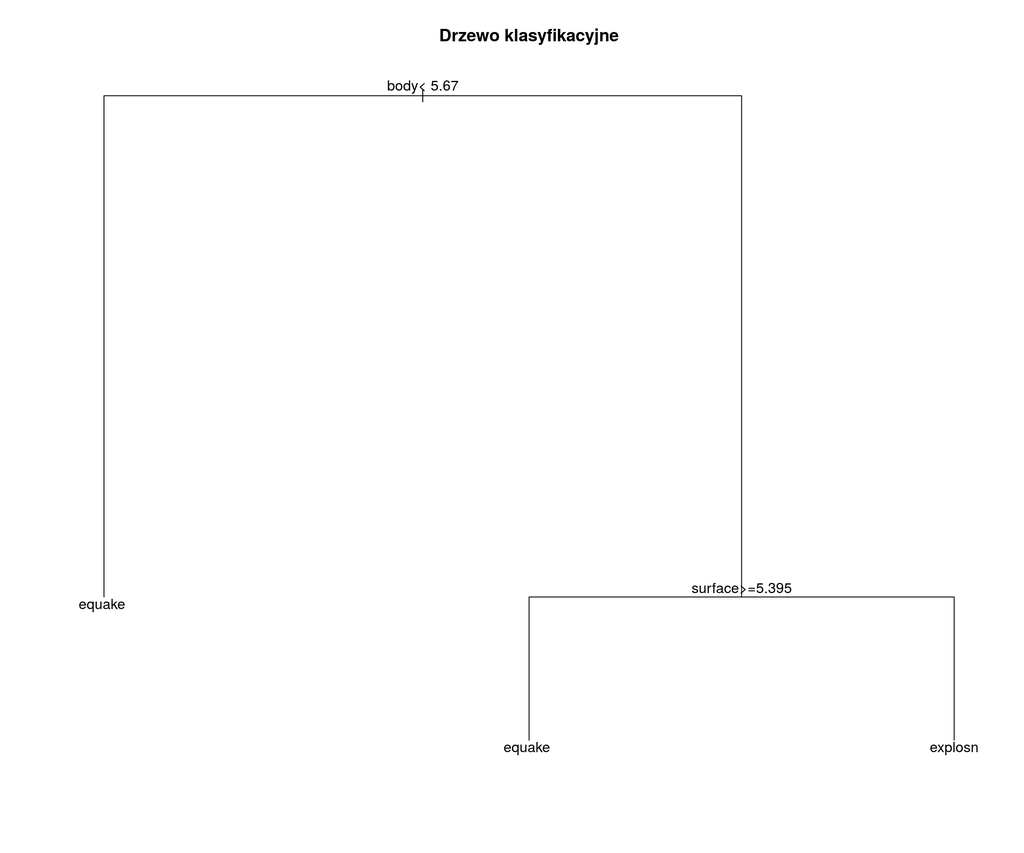

```r
model.tree <- rpart(as.factor(popn) ~ ., data = dane, minsplit = 5)

plot(model.tree)
text(model.tree)
title("Drzewo klasyfikacyjne")
```

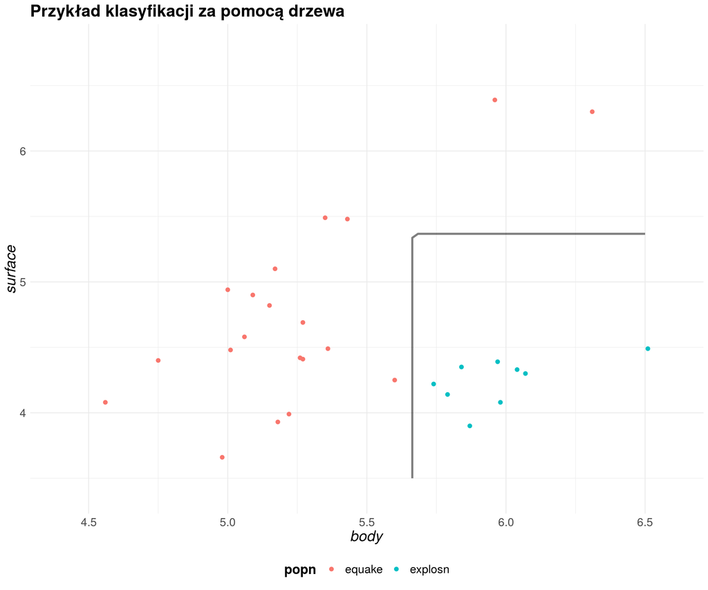

```r
xp <- seq(4.5, 6.5, length = 50)
yp <- seq(3.5, 6.5, length = 50)
siatka <- expand.grid(body = xp, surface = yp)

P1 <- predict(model.tree, newdata = siatka, type = "prob")
zp1 <- ifelse(P1[,1] == 1, 1, -1)

ggplot() + xlim(c(4.4, 6.6)) + ylim(c(3.4, 6.8)) + theme_minimal() +
  geom_contour(data = cbind(siatka, data.frame(pred2 = zp1)),
               aes(x = body, y = surface, z = pred2), bins = 1, col = "black",
               linetype = 1, size = 1.2, alpha = 0.5) +
  geom_point(data = dane, aes(x = body, y = surface, col = popn), size = 2) +
  xlab("body") + ylab("surface") + ggtitle("Przykład klasyfikacji za pomocą drzewa") +
  theme(plot.title = element_text(face = "bold", size = 20)) +
  theme(axis.title.x = element_text(size = 18, angle = 0, face = "italic"),
        axis.title.y = element_text(size = 18, angle = 90, face = "italic")) +
  theme(axis.text= element_text(size = 14)) +
  theme(legend.title = element_text(size = 16, face = "bold")) +
  theme(legend.text = element_text(colour = "black", size = 14),
        legend.position = "bottom") +
  guides(color = guide_legend(keywidth = 2, keyheight = 2))
```

Wracamy do danych opisujących zatonięcie Titanica. Najpierw wyznaczymy optymalny parametr cp metodą kroswalidacji i regułą 1SE:

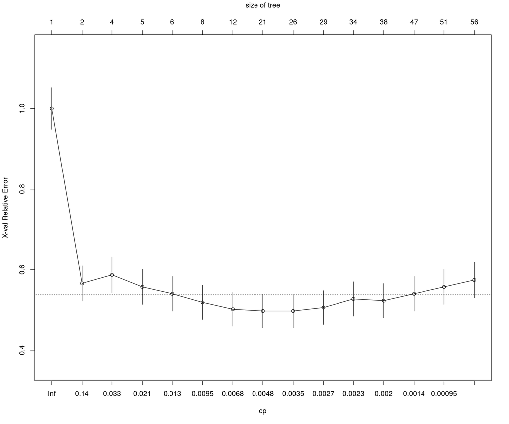

```r
tree.tmp <- rpart(factor(Survived)~., data = train, cp = 0.0001, minsplit = 5)
plotcp(tree.tmp)
```

```r
printcp(tree.tmp)
```

```
##
## Classification tree:
## rpart(formula = factor(Survived) ~ ., data = train, cp = 1e-04,
##     minsplit = 5)
##
## Variables actually used in tree construction:
## [1] Age       EmbarkedS Fare      Parch     Pclass    Sexfemale SibSp
##
## Root node error: 235/624 = 0.3766
##
## n= 624
##
##            CP nsplit rel error  xerror     xstd
## 1  0.43404255      0   1.00000 1.00000 0.051505
## 2  0.04255319      1   0.56596 0.56596 0.043532
## 3  0.02553191      3   0.48085 0.58723 0.044116
## 4  0.01702128      4   0.45532 0.55745 0.043291
## 5  0.01063830      5   0.43830 0.54043 0.042798
## 6  0.00851064      7   0.41702 0.51915 0.042157
## 7  0.00547112     11   0.38298 0.50213 0.041625
## 8  0.00425532     20   0.32766 0.49787 0.041489
## 9  0.00283688     25   0.30638 0.49787 0.041489
## 10 0.00255319     28   0.29787 0.50638 0.041760
## 11 0.00212766     33   0.28511 0.52766 0.042417
## 12 0.00182371     37   0.27660 0.52340 0.042287
## 13 0.00106383     46   0.25957 0.54043 0.042798
## 14 0.00085106     50   0.25532 0.55745 0.043291
## 15 0.00010000     55   0.25106 0.57447 0.043768
```

Sprawdźmy, które drzewo jest lepsze:

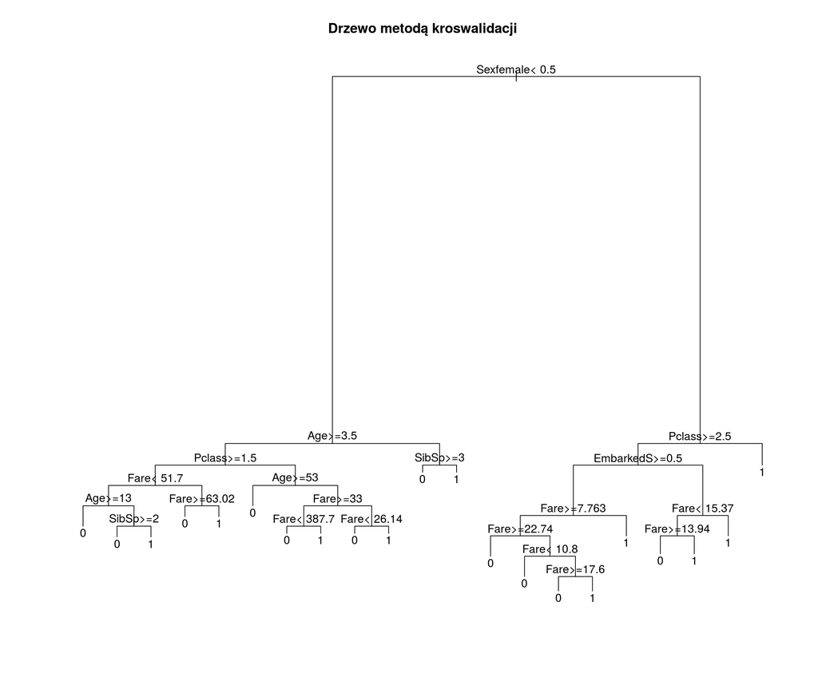

```r
tree.cross <- prune(tree.tmp, cp = 0.00547112)
plot(tree.cross)
text(tree.cross)
title("Drzewo metodą kroswalidacji")
```

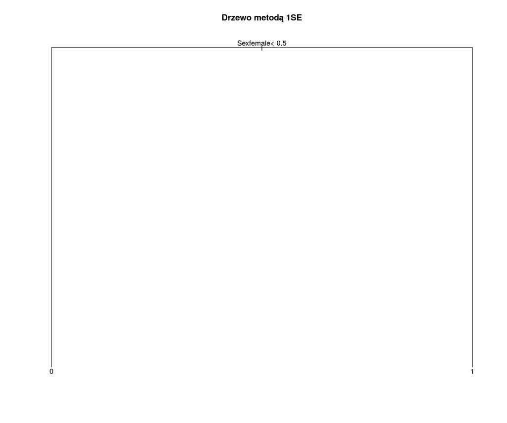

```r
tree.1se <- prune(tree.tmp, cp = 0.04682312)
plot(tree.1se)
text(tree.1se)
title("Drzewo metodą 1SE")
```

Wyniki klasyfikacji wyboru cp metodą kroswalidacji:

```r
pred.cross <- predict(tree.cross, test, type = "class")
c3 <- check_class(test$Survived, pred.cross)
c3
```

```
##  % popr. odp.       czułość      precyzja specyficzność
##     0.8426966     0.7289720     0.8571429     0.8352273
```

Wyniki klasyfikacji wyboru cp metodą 1SE:

```r
pred.1se <- predict(tree.1se, test, type = "class")
c4 <- check_class(test$Survived, pred.1se)
c4
```

```
##  % popr. odp.       czułość      precyzja specyficzność
##     0.7865169     0.6635514     0.7717391     0.7942857
```

Za pomocą klasyfikacji pojedynczym drzewem nie jesteśmy w stanie wprost określić, które zmienne są istotne w modelu a które nie. Możemy jednak posłużyć się następującym algorytmem. Następującą procedurę powtarzamy wystarczającą liczbę razy:

- wybieramy ok. 70% obserwacji
- budujemy drzewo na podstawie wybranej próbki
- sprawdzamy czy zmienna została wykorzystana w budownie tego drzewa

```r
n <- nrow(train)
n1 <- floor(n*0.7)
lp <- 300
zmienne <- c("1")
zmienne.bezpowt <- c("1")
m <- 0
cp_opt <- 0.00547112
for(i in 1:lp){
  m <- m + 1
  pseud <- sample(1:n, n1)
  tmp.tree <- rpart(factor(Survived)~., data = train[pseud,], cp = cp_opt, minsplit = 5)
  zmienne <- c(zmienne, tmp.tree$frame$var)
  zmTMP <- sort(tmp.tree$frame$var) %>% as.character()
  zmTMP <- zmTMP[zmTMP!="<leaf>"]
  zmTMP.bezpowt <- c("1")
  for(i in 2:length(zmTMP)){
    if(zmTMP[i]!= zmTMP[i-1])
      zmTMP.bezpowt <- c(zmTMP.bezpowt, as.character(zmTMP[i]))
  }

  zmienne.bezpowt <- c(zmienne.bezpowt, zmTMP.bezpowt)
}

print(table(zmienne.bezpowt)[-1])
```

```
## zmienne.bezpowt
## EmbarkedQ EmbarkedS      Fare     Parch    Pclass Sexfemale     SibSp
##        70       209       300       121       300       300       267
```

Widzimy, że zmienne takie jak Fare, Pclass, Sexfemale, SibSp wystąpiły w budowie drzewa w ponad 2/3 przypadków. Są to zmienne istotne w tworzeniu klasyfikatora za pomocą drzew.

# Porównanie wyników:

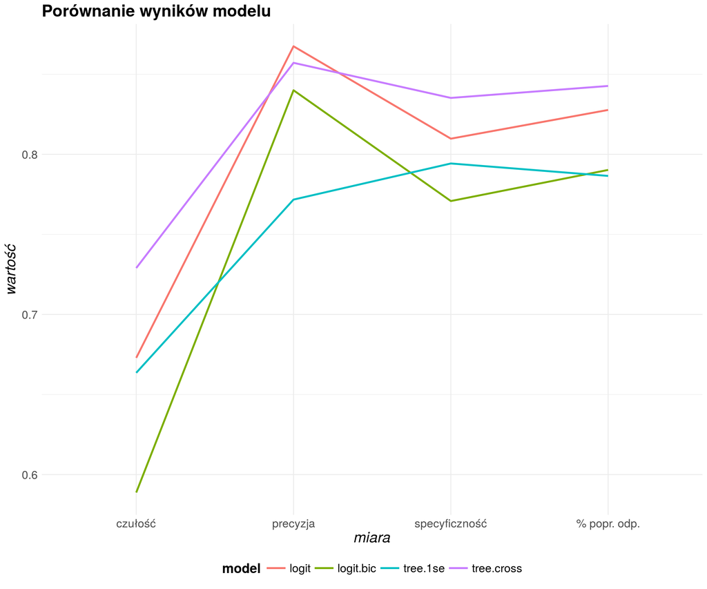

```r
podsumowanie <- data.frame(
  wyniki = c(c1,c2,c3,c4), miary = rep(names(c1),4),
  model = rep(c("logit.bic", "logit", "tree.cross", "tree.1se"), each = 4))

ggplot(podsumowanie, aes(x = as.factor(miary), y = wyniki, group = model, col = model)) + geom_line(size = 1.1) + theme_minimal() +
  xlab("miara") + ylab("wartość") + ggtitle("Porównanie wyników modelu") +
  theme(plot.title = element_text(face = "bold", size = 20)) +
  theme(axis.title.x = element_text(size = 18, angle = 0, face = "italic"),
        axis.title.y = element_text(size = 18, angle = 90, face = "italic")) +
  theme(axis.text= element_text(size = 14)) +
  theme(legend.title = element_text(size = 16, face = "bold")) +
  theme(legend.text = element_text(colour = "black", size = 14),
        legend.position = "bottom") +
  guides(color = guide_legend(keywidth = 2, keyheight = 2))
```